# Progress Report of Economics Research Lab - Work Sample Originally Written 03-20-2025

Agustin Pace

11-28-2025

# Notes for the Institute for Policy Integrity Application

Below you will find a progress report I wrote at the end of a term for the Economics Urban Issues Research Lab that I was a part of at Santa Clara University. The goal of the project was to analyze the effects of shelter openings on the level of crime in California cities. My job at this stage of the project was to geolocate all the shelters in the city of San Jose. I mapped them by how long they have been open and their size. This report was created using R-Markdown.

HIC stands for The Housing Inventory Count. It is a point-in-time count of people that are experiencing homelessness. We extracted the data from the U.S. Department of Housing and Urban Development, and the dataset can be filtered down to the desired city level.

# Introduction

This script is a brief report on our lab’s work this past quarter on the relationship between crime and homeless shelters in the Bay Area. In the previous quarter, we looked at the role of ADU’s and whether they serve as a viable solution to the growing issue of housing affordability in the area. This quarter, the focus was on the potential community effects of building affordable housing. In particular, whether building more affordable housing in areas of high homelessness may lead to less crime. With the Bay Area having a growing reputation of higher crime and homelessness,[^1] analyzing potential solutions to the issue would serve useful to those in policy making and the police force.

Previous research on the topic has been conducted by Elior Cohen, who wrote a paper on the effect of homeless housing sites in Los Angeles County.[^2] He suggests in his research that communities with greater housing experienced a decline in overall and homeless related crime. Given that, some of the work done by the lab this quarter is analyzing and replicating the work Cohen has done in Los Angeles but in the Bay Area, to see if a similar relationship can be found.

# Graphical Representations of Shelters in San Jose

Below is a map of all the locations of shelters in the city of San Jose. Dot size and color are based on their age and size. Size is determined by the number of total beds the shelter has. The darker the shade then the older the shelter is relative to the others around it.

Age is calculated by indexing it at 0 from 2024, and counting upwards for every occurrence that the shelter is also identified in a previous year. So, if a shelter has been around since at least 2020, it should have an age of 4 on this map.

```r
geolocated_shelters <- read.csv("~/Downloads/geocoded_shelters_all - geocoded_shelters_all-2.csv")


# Extract and clean longitude from 'geometry' column
geolocated_shelters <- geolocated_shelters %>%
  mutate(
    longitude = as.numeric(str_replace(geometry, "c\\(", "")), # Remove "c("
    latitude = as.numeric(str_replace(Age, "\\)", ""))  # Remove ")"
  )

geolocated_shelters <- geolocated_shelters %>%
  select(-geometry, -Age)

#convert geolocated_shelters into an sf object for mapping
geolocated_shelters <- st_as_sf(geolocated_shelters, coords = c("longitude", "latitude"), crs = 4326)

geolocated_shelters <- geolocated_shelters |>
  filter(`City` != "Beverly Hills")

# Count occurrences of each shelter based on its address
geolocated_shelters <- geolocated_shelters %>%
  group_by(Project.Name, Address, City, State, Zip) %>%
  mutate(Age = 2024 - year) %>%  # Age is the difference from 2024
  ungroup()


# Filter for only the city of San Jose
geolocated_shelters_SJ <- geolocated_shelters %>%
  filter(City == "San Jose")


# Enable interactive mode
tmap_mode("view")

# Map with hover-over and size-based scaling
tm_shape(geolocated_shelters_SJ) +
  tm_dots(
    col = "Age",
    palette = "Blues",
    size = "Total.Beds",  # Adjust dot size based on the Beds column
    id = "Project.Type"  # Show Project.Type when hovering
  ) +
  tm_layout(title = "Shelter Age and Size by Location")
```

[interactive chart not shown]

From the map, we can visually see how most of the larger shelters in the city of San Jose are located near the downtown. By far the biggest one is downtown, holding 1,374 beds. Many of these shelters have been around for many years, but there are still newer shelters that appeared to have been built in the last four years. From this visual view, there does not appear to be a conclusive pattern between where they are built and how old they are. Some are downtown while others appear further out into the suburbs.

# Plot of Shelters in San Jose Over Time

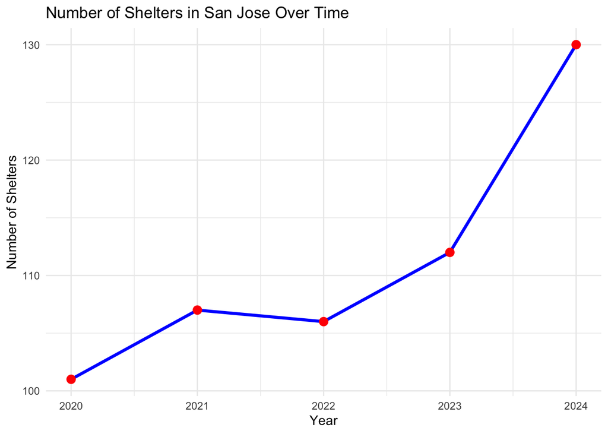

```r
# Count the number of shelters per year
total_shelter_counts <- geolocated_shelters %>%
  group_by(year) %>%
  summarise(Num_Shelters = n())  # Count number of shelters each year

# Count the number of shelters per year in San Jose
shelter_counts_SJ <- geolocated_shelters_SJ %>%
  group_by(year) %>%
  summarise(Num_Shelters = n())  # Count number of shelters each year

# Plot the trend
ggplot(shelter_counts_SJ, aes(x = year, y = Num_Shelters)) +
  geom_line(color = "blue", size = 1.2) +
  geom_point(color = "red", size = 3) +
  labs(title = "Number of Shelters in San Jose Over Time",
       x = "Year",
       y = "Number of Shelters") +
  theme_minimal()
```

Other than one less shelter after 2021, every other year has seen the total number of shelters grow. Both in 2020 and 2022, the number of shelters grew by 6, while the year 2023 saw the largest growth in the amount of shelters having been built at 18. For now it is unclear what may have caused this, and it would be interesting to see if it also correlates with the total number of homeless in San Jose.

# Projects and Code from the Last Two Weeks

My tasks for the past two weeks was to clean the raw HIC count data, and then geolocate them. The culmination of the work is what was seen above in the map and plot, but below is the code for how the process was accomplished.

## Part 1. Identifying and cleaning HIC data

CSVs for the HIC raw counts were read into R, and then they were cleaned to only include shelters in the Bay Area. The datasets were then grouped by Project Type so that the total number of beds and PIT count were counted for each project type.

There were some issues when trying to clean the data from 2015-2019, where for three of those years, some of the raw data are missing at least one of the key values such as address, bed counts, and/or pit counts, etc. This lead to them having 0 observations for the variables because the code drops any shelter that is missing at least one of them. It leads to empty datasets in other words. Later work will try to troubleshoot the issue so those years can be included in the analysis.

```r
# HIC_2024 <- read.csv("~/Documents/Santa Clara University/Econ/ECON 192 W Quarter/2024-HIC-Counts-by-State.csv")

# HIC_2023 <- read.csv("~/Documents/Santa Clara University/Econ/ECON 192 W Quarter/2023-HIC-Counts-by-State.csv")
#
# HIC_2022 <- read.csv("~/Documents/Santa Clara University/Econ/ECON 192 W Quarter/2022-HIC-Counts-by-State.csv")

# HIC_2021 <- read.csv("~/Documents/Santa Clara University/Econ/ECON 192 W Quarter/2021-HIC-Counts-by-State.csv")

# HIC_2020 <- read_excel("~/Documents/Santa Clara University/Econ/ECON 192 W Quarter/HIC Raw Counts/2020-HIC-Raw-File.xlsx")

# HIC_2019 <- read_excel("~/Documents/Santa Clara University/Econ/ECON 192 W Quarter/HIC Raw Counts/2019-Housing-Inventory-County-RawFile.xlsx")



# HIC_2019bay <- HIC_2019 |>
#   filter(CocState == "CA" & HudNum %in% c("CA-500", "CA-501", "CA-502")) |>
#   select(year, `Organization Name`, `Project Name`, `Project Type`, address1, city,
#          state, zip, `PIT Count`, `Total Beds`) |>
#   mutate(
#     Address = proper_case(address1),
#     City = proper_case(city),
#     State = state,
#     Zip = str_replace(zip, "#", "")
#   ) |>
#   select(-address1, -city, -state, -zip) |>
#   filter(complete.cases(across(everything())))


# HIC_2019bay |>
#   group_by(`Project Type`) |>
#   summarize(
#     TotalProjects = n(),
#     TotalPitCount = sum(`PIT Count`, na.rm = TRUE),
#     TotalBeds = sum(`Total Beds`, na.rm = TRUE)
#   )
#
# write.csv(HIC_2019bay, "~/Documents/Santa Clara University/Econ/ECON 192 W Quarter/HIC_2019bay.csv", row.names = FALSE)
```

## Part 2. Geolocating Cleaned HIC data

After cleaning the raw HIC files in one R script, I read them into another to do the geolocating.

The objective was to optimize the code so that the shelters that needed geolocating were those that were not already geolocated. In this code, 2024 was already geolocated and read in. A dataset of existing addresses were created for 2024. Afterwards, after the cleaned HIC data was read in, the addresses for 2023 were extracted, before identifying which addresses matched between 2024 and 2023. The ones that were not matched were put in a dataset of addresses that needed geolocating, and then they were geolocated using tidygeocoder. All the shelters were then binded.

This proved challenging, as some of the column names had different syntax across the different years, which was missed in the initial cleaning process. This led to issues in the binding process, where even though addresses that needed geolocating were correctly identified, they were then the only ones that were considered to be all the shelters for a certain year, instead of also adding the previously matched addresses from the following year.

In the end, I manually geolocated the years 2020-2023 for the sake of having the correct datasets for analysis, not just for myself but for everyone involved in the project, but I think it would be important to collaboratively go over this code to find potential fixes to the issues.

```r
#
# GeolocatedHIC_2024 <- read.csv("~/Documents/Santa Clara University/Econ/ECON 192 W Quarter/geocoded_shelters_bay 2024-2.csv")
#
# GeolocatedHIC_2024 <- GeolocatedHIC_2024 %>%
  #rename(year = Year) # Ensures consistency (safe to run)


#GeolocatedHIC_2024 <- GeolocatedHIC_2024 %>%
  #rename(PIT.Count = Pit.Count)

#
# # Extract only standardized addresses (remove spatial component for comparison)
# existing_addresses_2024 <- GeolocatedHIC_2024 %>%
#   st_drop_geometry() %>%
#   mutate(Full_Address = paste(Address, City, State, Zip, sep = ", ")) %>%
#   select(Full_Address) %>%
#   distinct
#
#
# HIC_2023 <- read.csv("~/Documents/Santa Clara University/Econ/ECON 192 W Quarter/HIC_2023bay.csv")
# HIC_2022 <- read.csv("~/Documents/Santa Clara University/Econ/ECON 192 W Quarter/HIC_2022bay.csv")
# HIC_2021 <- read.csv("~/Documents/Santa Clara University/Econ/ECON 192 W Quarter/HIC_2021bay.csv")
# HIC_2020 <- read.csv("~/Documents/Santa Clara University/Econ/ECON 192 W Quarter/HIC_2020bay.csv")
# HIC_2019 <- read.csv("~/Documents/Santa Clara University/Econ/ECON 192 W Quarter/HIC_2019bay.csv")
# HIC_2018 <- read.csv("~/Documents/Santa Clara University/Econ/ECON 192 W Quarter/HIC_2018bay.csv")
# HIC_2017 <- read.csv("~/Documents/Santa Clara University/Econ/ECON 192 W Quarter/HIC_2017bay.csv")
# HIC_2016 <- read.csv("~/Documents/Santa Clara University/Econ/ECON 192 W Quarter/HIC_2016bay.csv")
# HIC_2015 <- read.csv("~/Documents/Santa Clara University/Econ/ECON 192 W Quarter/HIC_2015bay.csv")


# # Standardize addresses
# addresses_to_lookup_2023 <- HIC_2023 %>%
#   mutate(Full_Address = paste(Address, City, State, Zip, sep = ", ")) %>%
#   select(everything(), Full_Address) # Retain all columns for later merging
#
# # Identify only **new** addresses that need geolocation
# to_geolocate_2023 <- addresses_to_lookup_2023 %>%
#   anti_join(existing_addresses_2024, by = "Full_Address") # Remove already geolocated shelters
#
# # Geocode using ArcGIS (change method if needed)
# lat_long_2023 <- to_geolocate_2023 %>%
#   tidygeocoder::geocode(address = Full_Address, method = "arcgis")
#
#
# # Convert to sf object for spatial compatibility
# geocoded_shelters_2023 <- st_as_sf(lat_long_2023, coords = c("long", "lat"), crs = 4326)
#
#
# geolocated_all <- bind_rows(GeolocatedHIC_2024, geocoded_shelters_2023)
#
# write.csv(geocoded_shelters_2023, "~/Documents/Santa Clara University/Econ/ECON 192 W Quarter/geocoded_shelters_2023.csv", row.names = FALSE)
#
# write.csv(geolocated_all, "~/Documents/Santa Clara University/Econ/ECON 192 W Quarter/geocoded_shelters_all.csv", row.names = FALSE)
```

I asked generative AI to see what kind of function could be used to automate the geolocating process for all the shelters across many more years. The idea was to do this for clean datasets all the way down to 2015.

```r
#
# geolocate_shelters <- function(year, existing_data) {
#   # Load shelters for the given year
#   shelters <- fread(paste0("~/Documents/Santa Clara University/Econ/ECON 192 W Quarter/Geolocated Shelters", year, ".csv"), data.table = FALSE)
#
#   # Standardize addresses
#   shelters <- shelters %>%
#     mutate(Full_Address = paste(Address, City, State, Zip, sep = ", ")) %>%
#     select(everything(), Full_Address)
#
#   # Remove already geolocated addresses
#   new_addresses <- shelters %>%
#     anti_join(existing_data %>% st_drop_geometry(), by = "Full_Address")
#
#   # If new addresses exist, geocode them
#   if (nrow(new_addresses) > 0) {
#     new_geocoded <- new_addresses %>%
#       tidygeocoder::geocode(address = Full_Address, method = "arcgis") %>%
#       st_as_sf(coords = c("long", "lat"), crs = 4326)
#
#     # Merge with existing geolocated data
#     updated_data <- bind_rows(existing_data, new_geocoded)
#
#     return(updated_data)
#   } else {
#     return(existing_data)  # No new shelters, return unchanged dataset
#   }
# }
#
# # Loop through previous years (2023, 2022, 2021, ...)
# geolocated_all <- GeolocatedHIC_2024
# for (year in 2023:2020) {  # Adjust as needed
#   geolocated_all <- geolocate_shelters(year, geolocated_all)
# }
#
# # Save final geolocated dataset
# #st_write(geolocated_all, "path/to/final_geolocated_shelters.shp", delete_dsn = TRUE)
```

More work has to be done to make sure that the cleaning process for the raw HIC data could be debugged so that then we can go through geolocating them as well. Once we get that working, I want to attempt to use the function above to do the geolocating. With a bigger sample, we can conduct a more robust analysis on the relationships between crime and shelters.

For now, in these past four years we still have three main cities in the Bay Area that we can use to conduct preliminary analysis.

[^1]: Heather Knight & Shawn Hubler, *“San Francisco’s Woes Are Well Known. Across the Bay, Oakland Has Struggled More.”* The New York Times, December 14, 2023. Available at: https://www.nytimes.com/2023/12/14/us/oakland-crime-economy-homelessness.html
[^2]: Cohen, Elior, The Effects of Designated Homeless Housing Sites on Local Communities: Evidence from Los Angeles County (December 28, 2019).